# 2.1-Análisis exploratorio de datos (EDA)

Jair Villanueva

4/4/2022

### Análisis Exploratorio de datos (EDA)

**Definición:**

Son técnicas estadísticas cuya finalidad es conseguir un entendimiento básico de los datos y de las relaciones existentes entre las variables analizadas de un dataset.

**Objetivos del EDA**

- Organizar y preparar los datos
- Detectar fallos en el diseño y recogida de los datos
- Manejo de datos faltantes
- Transformar/eliminar/agregar/ordenar datos
- Identificación de casos atípicos (outliers)
- Encontrar relaciones entre variables
- Aplicar técnicas estadísticas para cada variable (Gráficas)

### Introducción

Las enfermedades cardiovasculares (ECV) o enfermedades del corazón son la principal causa de muerte en todo el mundo con 17,9 millones de casos de muerte cada año . Las enfermedades cardiovasculares se deben a la hipertensión, la diabetes, el sobrepeso y los estilos de vida poco saludables. Puede leer más sobre las estadísticas de enfermedades cardíacas y las causas de la autocomprensión. Este proyecto cubre el análisis exploratorio de datos usando R. El conjunto de datos utilizado en este proyecto es el conjunto de datos de enfermedades cardíacas (“heart.csv”), y tanto los datos como el código para este proyecto están disponibles en mi repositorio de GitHub https://github.com/jairvilla/EW3006_DataSciencexHC.git.

**Información de las variables del dataset:**

1)**age:** Age of the patient, in years

2)**sex:** (1= male, 0 = female)

3)**cp:** chest pain type (4 values) Value 1: typical angina Value 2: atypical angina Value 3: non-anginal pain Value 4: asymptomatic

4)**trestbps** resting blood pressure

5)**chol:** serum cholestoral in mg/dl

6)**fbs:** fasting blood sugar > 120 mg/dl (1 = true, 0 = false)

7)**restecg:** resting electrocardiographic results (values 0,1,2) Value 0:normal, Value 1: having ST-T wave abnormality, Value 2: showing probable or definite left ventricular hypertropy by Estes

8)**thalach:** maximum heart rate achievecd

9)**exang:** exercise induced angina (1 = yes, 0 = no)

10)**oldpeak:** = ST depression induced by exercise relative to rest

11)**slope:** the slope of the peak exercise ST segment 12).ca: number of major vessels (0-3) colored by flourosopy

13**thal:** 3 = normal; 6 = fixed defect; 7 = reversable defect

14)**diagnosis:** Diagnoses of heart disease (Value 0: non-diseased, Value 1: diseased)

### Dataset: *“heart.csv”*

Los datos de enfermedades cardíacas están disponibles en [UCI](https://archive.ics.uci.edu/ml/machine-learning-databases/heart-disease/processed.cleveland.data). La descripción de la base de datos se puede encontrar [aquí](https://archive.ics.uci.edu/ml/machine-learning-databases/heart-disease/heart-disease.names).

```r
heart <- read.csv("./data/heart.csv", sep = ";", header = TRUE )
# glimpse(heart)   # Resumir los datos
summary(heart)     # Estadistica descriptiva
```

```
##        id             age             sex               cp
##  Min.   :  1.0   Min.   : 2.00   Min.   :0.0000   Min.   :1.000
##  1st Qu.: 76.5   1st Qu.:47.00   1st Qu.:0.0000   1st Qu.:3.000
##  Median :152.0   Median :55.00   Median :1.0000   Median :3.000
##  Mean   :152.0   Mean   :54.11   Mean   :0.6799   Mean   :3.158
##  3rd Qu.:227.5   3rd Qu.:61.00   3rd Qu.:1.0000   3rd Qu.:4.000
##  Max.   :303.0   Max.   :77.00   Max.   :1.0000   Max.   :4.000
##                  NA's   :10
##     trestbps           chol            fbs            restecg
##  Min.   :  94.0   Min.   :126.0   Min.   :0.0000   Min.   :0.0000
##  1st Qu.: 120.0   1st Qu.:212.0   1st Qu.:0.0000   1st Qu.:0.0000
##  Median : 130.0   Median :243.0   Median :0.0000   Median :1.0000
##  Mean   : 145.9   Mean   :247.8   Mean   :0.1485   Mean   :0.9901
##  3rd Qu.: 140.0   3rd Qu.:277.0   3rd Qu.:0.0000   3rd Qu.:2.0000
##  Max.   :2000.0   Max.   :564.0   Max.   :1.0000   Max.   :2.0000
##  NA's   :10       NA's   :20
##     thalach           exang           oldpeak         slope
##  Min.   :  22.0   Min.   :0.0000   Min.   :0.00   Min.   :1.000
##  1st Qu.: 133.0   1st Qu.:0.0000   1st Qu.:0.00   1st Qu.:1.000
##  Median : 153.0   Median :0.0000   Median :0.80   Median :2.000
##  Mean   : 161.9   Mean   :0.3267   Mean   :1.04   Mean   :1.601
##  3rd Qu.: 166.0   3rd Qu.:1.0000   3rd Qu.:1.60   3rd Qu.:2.000
##  Max.   :1710.0   Max.   :1.0000   Max.   :6.20   Max.   :3.000
##  NA's   :10
##        ca                 thal                diag
##  Min.   :-100000.0   Min.   :-100000.0   Min.   :0.0000
##  1st Qu.:      0.0   1st Qu.:      3.0   1st Qu.:0.0000
##  Median :      0.0   Median :      3.0   Median :0.0000
##  Mean   :   -659.2   Mean   :   -655.4   Mean   :0.4587
##  3rd Qu.:      1.0   3rd Qu.:      7.0   3rd Qu.:1.0000
##  Max.   :      4.0   Max.   :      7.0   Max.   :1.0000
##
```

Teniendo en cuenta el tipo de variables del dataset, se observa que algunas varibles son tipo categoricas (*sex*, *ca*,*diag*) y otros son numéricas(*age*,*chol*,*…*). Sin embargo, el análisis previo muestra todas las variables como númericas.

### Preparación de los datos

```r
# Identificar datos faltantes
sum(is.na(heart))      # Cuenta el total de NAs del dataset
```

```
## [1] 50
```

```r
colSums(is.na(heart))  # Calcular el total de NA de cada variable
```

```
##       id      age      sex       cp trestbps     chol      fbs  restecg
##        0       10        0        0       10       20        0        0
##  thalach    exang  oldpeak    slope       ca     thal     diag
##       10        0        0        0        0        0        0
```

### Identificación de *“outliers”*:

La variable trestbps(presión arterial) tiene un valor máx de 2000, lo cual es atípico. Por esta razón debemos, reemplazar los outliers por la media o por un valor más racional.

```r
library(outliers)        # librería
outlier(heart$trestbps)  # Identificar posibles valores atípicos de cada variable.
```

```
## [1] 2000
```

```r
outlier(heart$thalach)
```

```
## [1] 1710
```

```r
outlier(heart$thal)
```

```
## [1] -1e+05
```

**Preguntas:** * 1. ¿Cuáles variables del dataset presentan outliers?  
* 2. ¿Cuántos valores faltantes hay en el conjunto de datos *heart*? * 3. ¿En qué variables se concentran los valores faltantes? * 4. ¿Cómo imputaría la media o la mediana de estos valores?

### Identificar Outliers usando boxplot:

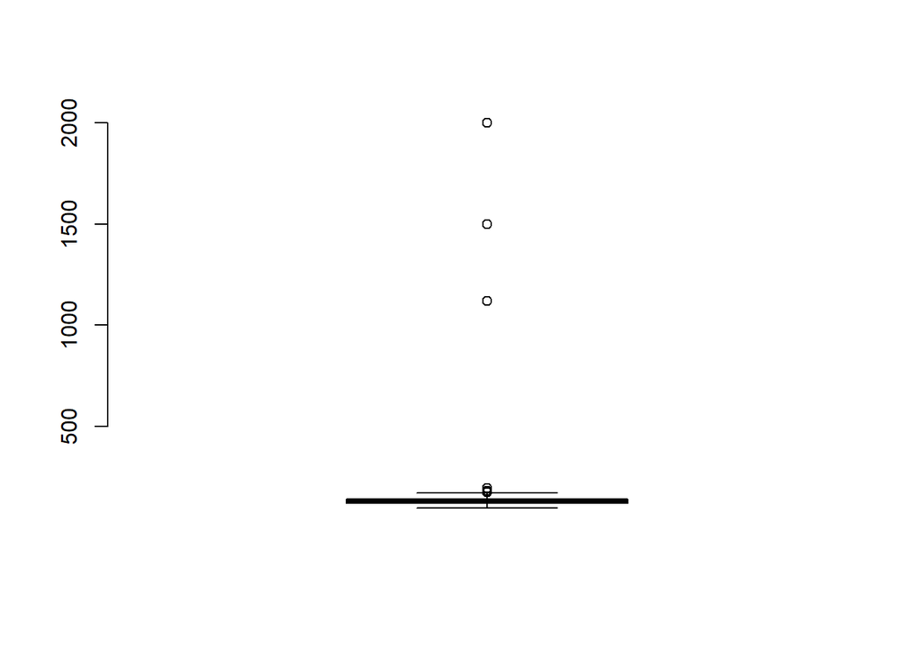

```r
# variable trestbps
outlier_v1 <- boxplot(heart$trestbps, col="skyblue", frame.plot= FALSE)
```

```r
outlier_v1$out
```

```
##  [1]  172 1500 1120  180 2000  174  178  192  180  178  180
```

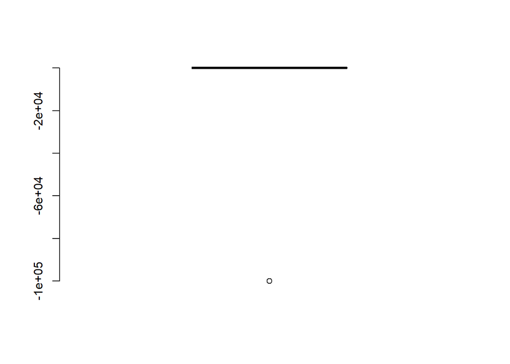

```r
# variable Thal
outlier_v2 <- boxplot(heart$thal, col="skyblue", frame.plot= FALSE)
```

```r
outlier_v2$out   # Cuantos
```

```
## [1] -1e+05 -1e+05
```

```r
# Entonces para eliminar los outliers usamos el operador pertenece %in% que funciona igual que el símbolo matemático ∈ que se usa en la teoría de conjuntos.
# heart <-heart[!(heart$trestbps %in% outlier_var$out),]  # Eliminar los outliers
```

Manejo de Outliers:

```r
# variable thalach
# La variable *thalach* tiene un valor atípico de 1710 y 22:
heart$thalach <- ifelse(heart$thalach >= 250 | heart$thalach < 30,
                        mean(heart$thalach),heart$thalach)

# variable thal: 3: normal, 6 fixed detect, 7:reversable defect

heart$thal <- factor(heart$thal)
str(heart$thal)
```

```
##  Factor w/ 4 levels "-1e+05","3","6",..: 3 2 4 2 2 2 2 2 4 4 ...
```

```r
heart$thal <- ifelse(heart$thal <= -700,
                        mode(heart$thal),heart$thal)
# Imputación de mean en NAs
#heart$age[is.na(heart$age)]<- round(mean(heart$age, na.rm = TRUE))
#heart$chol[is.na(heart$chol)]<- round (mean(heart$chol, na.rm = TRUE))
#heart$trestbps[is.na(heart$chol)]<- round (mean(heart$chol, na.rm = TRUE))
#heart$chol[is.na(heart$chol)]<- round (mean(heart$chol, na.rm = TRUE))


#heart_mod <- heart %>%
#  dplyr::select(-id)%>%     # Eliminar Variable id
```

**Avanzado:** Creando un ciclo for

```r
for(i in 1:ncol(heart)){
  heart[is.na(heart[,i]), i] <- mean(heart[,i], na.rm = TRUE)
    }
summary(heart)
```

```
##        id             age             sex               cp
##  Min.   :  1.0   Min.   : 2.00   Min.   :0.0000   Min.   :1.000
##  1st Qu.: 76.5   1st Qu.:47.50   1st Qu.:0.0000   1st Qu.:3.000
##  Median :152.0   Median :55.00   Median :1.0000   Median :3.000
##  Mean   :152.0   Mean   :54.11   Mean   :0.6799   Mean   :3.158
##  3rd Qu.:227.5   3rd Qu.:61.00   3rd Qu.:1.0000   3rd Qu.:4.000
##  Max.   :303.0   Max.   :77.00   Max.   :1.0000   Max.   :4.000
##
##     trestbps           chol            fbs            restecg
##  Min.   :  94.0   Min.   :126.0   Min.   :0.0000   Min.   :0.0000
##  1st Qu.: 120.0   1st Qu.:214.0   1st Qu.:0.0000   1st Qu.:0.0000
##  Median : 130.0   Median :246.0   Median :0.0000   Median :1.0000
##  Mean   : 145.9   Mean   :247.8   Mean   :0.1485   Mean   :0.9901
##  3rd Qu.: 140.0   3rd Qu.:274.0   3rd Qu.:0.0000   3rd Qu.:2.0000
##  Max.   :2000.0   Max.   :564.0   Max.   :1.0000   Max.   :2.0000
##
##     thalach          exang           oldpeak         slope
##  Min.   : 71.0   Min.   :0.0000   Min.   :0.00   Min.   :1.000
##  1st Qu.:136.0   1st Qu.:0.0000   1st Qu.:0.00   1st Qu.:1.000
##  Median :152.0   Median :0.0000   Median :0.80   Median :2.000
##  Mean   :149.4   Mean   :0.3267   Mean   :1.04   Mean   :1.601
##  3rd Qu.:165.0   3rd Qu.:1.0000   3rd Qu.:1.60   3rd Qu.:2.000
##  Max.   :202.0   Max.   :1.0000   Max.   :6.20   Max.   :3.000
##
##        ca                 thal          diag
##  Min.   :-100000.0   Min.   : NA   Min.   :0.0000
##  1st Qu.:      0.0   1st Qu.: NA   1st Qu.:0.0000
##  Median :      0.0   Median : NA   Median :0.0000
##  Mean   :   -659.2   Mean   :NaN   Mean   :0.4587
##  3rd Qu.:      1.0   3rd Qu.: NA   3rd Qu.:1.0000
##  Max.   :      4.0   Max.   : NA   Max.   :1.0000
##                      NA's   :303
```